# Future's league,

### Team : Excellent in Analysis

#### 팀장 경북대학교 정재훈, 팀원 박준수 김민기 김동언 우지수

```python
import pandas as pd
import numpy as np
import warnings
warnings.filterwarnings(action='ignore')

from numpy.random import seed
from sklearn import model_selection
from sklearn.metrics import roc_curve
from sklearn.metrics import auc
from sklearn.metrics import roc_auc_score
from sklearn.model_selection import GridSearchCV
from sklearn.metrics import roc_auc_score

import lightgbm
import datetime
```

## 전처리

- 전처리 과정의 대부분 Samsung Brightics Studio, Excel, Python을 이용했습니다. 파이썬을 이용한부분만 아래에 두겠습니다.

데이터 불러오기

```python
AFSNT = pd.read_csv('AFSNT.csv', engine = 'python')
AFSNT_DLY = pd.read_csv('AFSNT_DLY.csv', engine = 'python')
```

```python
AFSNT_raw = AFSNT.copy()
AFSNT_DLY_raw = AFSNT_DLY.copy()
```

CNR 즉 결항은 주요관심사가 아니었기 떄문에 결항여부를 포함하고있는  
결항했던 데이터들은 모두 제거하고 결항에 관련된 열들을 제거 (CNL, CNR)

```python
AFSNT.head()
```

|  | SDT_YY | SDT_MM | SDT_DD | SDT_DY | ARP | ODP | FLO | FLT | REG | AOD | IRR | STT | ATT | DLY | DRR | CNL | CNR |
| --- | --- | --- | --- | --- | --- | --- | --- | --- | --- | --- | --- | --- | --- | --- | --- | --- | --- |
| 0 | 2017 | 1 | 1 | 일 | ARP3 | ARP6 | J | J1955 | SEw3NzE4 | D | N | 10:05 | 10:32 | N | NaN | N | NaN |
| 1 | 2017 | 1 | 1 | 일 | ARP3 | ARP6 | J | J1954 | SEw3NzE4 | A | N | 9:30 | 9:31 | N | NaN | N | NaN |
| 2 | 2017 | 1 | 1 | 일 | ARP3 | ARP6 | J | J1956 | SEw3NzE4 | A | N | 12:45 | 13:03 | N | NaN | N | NaN |
| 3 | 2017 | 1 | 1 | 일 | ARP3 | ARP6 | J | J1957 | SEw3NzE4 | D | N | 13:25 | 14:09 | Y | C02 | N | NaN |
| 4 | 2017 | 1 | 1 | 일 | ARP3 | ARP6 | J | J1958 | SEw3NzE4 | A | N | 16:10 | 16:31 | N | NaN | N | NaN |

```python
AFSNT = AFSNT[AFSNT['CNR'].isna() == True]
```

Test data의 정확한 예측 및 데이터의 경량화를 위해 Test data에 포함되어있는 항공사를  
포함하고있는 Train set만 추출

```python
AFSNT = AFSNT[(AFSNT['FLO'] == 'A') | (AFSNT['FLO'] == 'B') | (AFSNT['FLO'] == 'F') |  (AFSNT['FLO'] == 'H') | (AFSNT['FLO'] == 'I') | (AFSNT['FLO'] == 'J') | (AFSNT['FLO'] == 'L') | (AFSNT['FLO'] == 'M')]
```

마찬가지의 이유로 9월 16일 ~ 9월 30일로 예정된 항공편들은 정기편에 해당하므로  
데이터에서 부정기편 데이터는 제거함.  
다만, 예외적으로 ARP10에 해당하는 공항은 모든 비행이 부정기편에 해당하므로 남기기로 결정  
그 후 IRR(정기편, 부정기편) 칼럼 제거

```python
temp1 = AFSNT[AFSNT['ODP'] == 'ARP10']
temp2 = AFSNT[AFSNT['ARP'] == 'ARP10']
AFSNT = AFSNT[AFSNT['IRR'] == 'N']
temptemp = pd.concat([AFSNT,temp1,temp2], axis = 0)
temptemp.drop(columns='IRR', inplace =True)
#temptemp.to_csv('preprocessing.csv', encoding = 'utf-8')
```

위 preprocessing.csv file을 각 팀원들이 맡은 부분에따라 유의미한 feature를 생성 하였습니다.  
대부분 Samsung Brightics Studio를 사용하여 해당과정은 아래에 설명하겠습니다.

## Features

> by Samsung Brights studio & Excel

#### SNA(Social Network Analysis)의 결과 변수

- degree  
  공항 노드의 degree 수
- between  
  공항 노드의 매개변수성
- edge  
  공항 노드 사이 edge 수

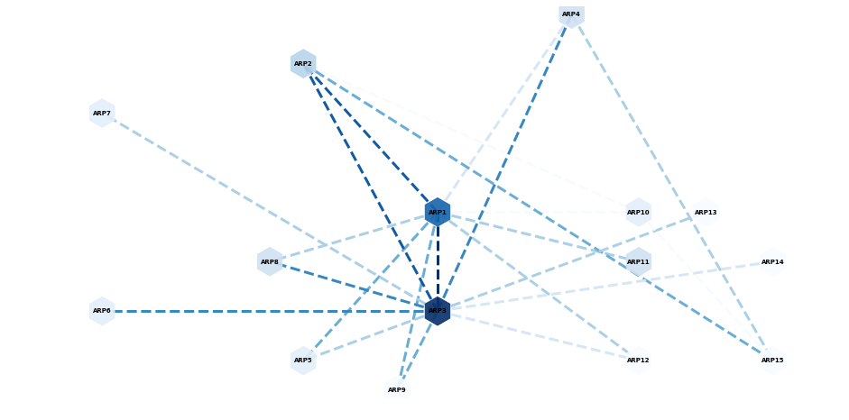

```python
import networkx as nx
import matplotlib.pyplot as plt
import numpy as np
import pandas as pd

def matrix_to_weight_network(matrix,ARP_list,node_weight): #matrix를 weight network로 변환
    G = nx.Graph()
    G.add_nodes_from([("ARP{}".format(i+1), {'weight': node_weight[i]}) for i in range(len(ARP_list))])
    for i in range(len(ARP_list)-1):
        for j in range(i + 1, len(ARP_list)):
            if (matrix[i, j] != 0):
                G.add_edge(ARP_list[i], ARP_list[j],weight=matrix[i,j])  # weight 가 있는 네트워크로 간주
    return G
# Train 불러오기
train=pd.read_csv("Full_Data_EDA.csv", engine= 'python')

# 행렬 생성
ARP_list = ['ARP1','ARP2','ARP3','ARP4','ARP5','ARP6','ARP7','ARP8','ARP9','ARP10','ARP11','ARP12','ARP13','ARP14','ARP15']

ARP_matrix = np.zeros((len(ARP_list),len(ARP_list)))

for i in range(train.shape[0]):
    row = ARP_list.index(train['ARP'][i])
    col = ARP_list.index(train['ODP'][i])
    ARP_matrix[row,col] += 1

node_weight =[9,4,11,3,2,2,2,3,1,2,3,1,1,1,1] #degree 값으로 node_weight 주기
G = matrix_to_weight_network(ARP_matrix,ARP_list,node_weight)
#print(G.degree())
B = nx.betweenness_centrality(G)
#print(B)
edge_list = [(u, v) for (u, v, d) in G.edges(data=True)]
edge_weight=[6,7,2,4,3,4,1,3,3,6,1,4,5,3,5,3,5,4,2,3,2,3,1] # edge 값을 확인하여 임의로 weight 조정


plt.figure(figsize=(16, 8))
plt.margins(x=0.1, y=0.02)

pos = {'ARP1':[2, -1.5], 'ARP2':[1, 0], 'ARP3':[2, -2.5], 'ARP4':[3, 0.5],
       'ARP5':[1, -3], 'ARP6':[-0.5, -2.5], 'ARP7':[-0.5, -0.5],
       'ARP8':[0.75, -2], 'ARP9':[1.7, -3.3],
       'ARP10':[3.5, -1.5], 'ARP11':[3.5, -2.0], 'ARP12':[3.5, -3], 'ARP13':[4.0, -1.5], 'ARP14':[4.5, -2.0], 'ARP15':[4.5, -3]}

nx.draw_networkx_nodes(G, pos, node_color=node_weight, node_shape='h',node_size=1000, cmap=plt.cm.Blues, alpha=0.9)
nx.draw_networkx_edges(G, pos, edge_color=edge_weight,width=3, edge_cmap=plt.cm.Blues,style='dashed')
nx.draw_networkx_labels(G, pos, font_family='sans-serif', font_color='black', font_size=7, font_weight='bold')
plt.axis('off')
plt.show()
```

#### 날씨변수

- cloud_height  
  운고
- visibility  
  시정거리
- mean_temp  
  평균온도
- mean_sea  
  평균 해수면 높이
- relative_humidity  
  평균 습도
- max_temp  
  최고 기온
- min_temp  
  최저 기온
- mean_wind  
  평균 풍속

#### 연결지연 관련 변수

- Accumulate  
  항공사별로 하루에 같은 편도에 대해서 순서를 매김

#### 요일 일자 관련 변수

연/월/요일/시간 변수 (One-hot encoding)

- SDT_YY_0~2  
  2017~2019년 연도 변수
- SDT_MM_0~11  
  1월 ~ 12월 월별 변수
- SDT_MM_0~6  
  월요일~일요일 요일 변수
- STT 0 ~ 23  
  00~24시 시간 변수